# Project working doc

The main grouping variables appear to be:

- Participant Private ID = unique participants
- branch-r1im = group, hard of hearing vs deaf

Filtering variables that can be used to clean the data:

- Response Type => only keep `action` (other types just timestamps of clicks)
- Key => rows with value `quantised` need to be filtered out (duplicates categorical answer with a useless numeric code - which 100% should not be used if calculating aggregates like means or medians)
- Object Name => remove `Comment Box` rows, these are free-text comments which likely can’t be aggregated/counted without coding/analyzing them manually first (if needed, LLM-driven automated annotation is an option, but principled coding scheme would still be required). These rows appear in the data even if the participant did not enter a comment (Response value is empty).
- But also some questions *only* consist of a comment box.

```
## 32475 rows after cleaning
```

Further operationalization and related issues:

- Questions appear to be identifiably via the Question and Object ID variables.
- **But** Question is not a reliable aggregation variable, as some contain corrupted strings/letters - seems to be a data export issue on client side.Object ID, is just an opaque code, so will create a more transparent new variable.
- Question numbering is challenging, e.g. these appear to be two unrelated questions that both are numbered as 10:
  - *(10).Kus või millal kasutad viipekeelt kõige rohkem?*
  - *(10.) Millised on peamised põhjused, mis takistavad sul viipekeelses tegevuses osalemast*
- And there is a question (11) which does not seem to be connected to questions numered (11-a,b,c) etc, although they look like subquestions of something:
  - *(11.) Kas oled huvitatud järgmistest viipekeelsetest tegevustest või kas sa oled mõnes neist juba osalenud?*
  - *(11-a) Ma tunnen end mugavalt, kui väljendan end eesti viipekeeles*
- Also there are sets of questions numbered the same where the first of the pair seems like metadata like sex and age, and the second is a free text question, e.g.:
  - (1.) Sugu:
  - (1.) Mis on peamine keel, millega end määratled? [a free text comment]
- Looking at Task Name, this is likely due to the dataset containing several tasks/questionnaires.
- `Ranking Scale` type in Object Name variable need some sort of wrangling (all values are relevant, should probably operationalize as a single value, but should it be first or average?)
- Some `Ranking Scale` type questions will be difficult to aggregate due to design, e.g. the question *(5.) Mis on Sinu põhiline suhtluskeel/suhtlusvahend?* (what is your main language of communication) seems to have forced participants to order all possible languages, including e.g. Ukrainian sign, which the participant might not speak at all, but there does not seem to have been an option to exclude non-relevant option, only to rank. An option to aggregate would be to consider only the primary/first pick of the participant (but this loses all the rest of the ranking info, which for some may be informative.)
- Other/don’t know/prefer not to say: some `Rating scale` questions have a categorical “don’t know” and Multiple choice have “other” type response option. These should likely be removed or set to NA if/when calculating numeric aggregates like means - unless not knowing or not preferring to answer is itself informative to the research question? If likert scales are operationalized here as categorical variables, then can be kept as they are.
  - **Problem** potentially however is linking them to their questions (for e.g. aggregation), their object IDs are unique. Sometimes they are appended with a letter to the question number, e.g. the “other” for (6.) is (6-d), also (9.) and (9-g) (letter seems random?) - but not always, and sometimes the appended letter seems to signify a completely different (maybe related) question.
  - Potential solution (needs client confirmation), it seems Page ID variable corresponds to questions, the “other” type options always have the same page number as question, whereas separate questions with appended letter do not (Page Counter variable does not work for this, hard to tell what it does but the numbers are the same for multiple questions). This info can be used to wrangle the data so that the “other” ones get the same question ID as the question. Will still filter out empty comments and “other” fields of course - *unless* the fact that a comments or other was not given is considered(?) informative.
- `Multiple Choice` in Object Name needs wrangling, again all (choices and non-choices) may be potentially relevant. Not sure how to handle them if counting across participants, should they be counted as they are, or (more likely) weighted 1/n_choices per participant? (otherwise participants who choose more options have more “weight”, more influence in the final aggregate).

This table summarizes the cleaned data so far:

| Question | QuestionID | Type | N | Top_values |
| --- | --- | --- | --- | --- |
| (1.) Mis on peamine keel, millega end määratled? | 1_ijey9g_177 | Comment Box | 151 | (Comments) |
| (1.) Sugu: | 1_31be3i_2 | Multiple Choice | 150 | (1-b) naine; (1-a) mees; (1-d) ei soovi vastata |
| (2.) Mis oli esimene keel, mille omandasid lapsena? | 2_8isowt_236 | Comment Box | 149 | (Comments) |
| (2.) Vanus: | 2_u18bdv_5 | Number Entry | 150 | 35; 33; 36; 45; 51; 52 |
| (3.) Kus Sa elad? | 3_mm4s4o_8 | Dropdown | 150 | Harjumaa; Tartumaa; Pärnumaa; Ida-Virumaa; Saaremaa; Viljandimaa |
| (3.) Millist keelt kasutad praegu kõige sagedamini? | 3_tbofp9_247 | Comment Box | 149 | (Comments) |
| (4.) Millist keelt kasutatakse praegu sinu kogukonnas kõige sagedamini? | 4_fp2kjp_258 | Comment Box | 149 | (Comments) |
| (4.) Palun määratle täpsemalt oma elukoht järgnevate hulgast: | 4_1scbsx_12 | Multiple Choice | 147 | (4-a) suurlinn; (4-b) väikelinn; (4-d) küla; (4-c) alev; (4-e) alevik |
| (5-a) Viipekeelsete kurtide kultuur saab edasi kesta ka ilma viipekeeleta. | 5_44tae4_169 | Rating Scale | 150 | 1; ei tea; 5; 2; 3; 4 |
| (5-b) Viipekeele hoidmine on minu jaoks oluline. | 5_kq2ep6_381 | Rating Scale | 150 | 5; 4; 1; 3; 2; ei soovi vastata |
| (5-c) Minu jaoks on oluline kasutada viipekeelt iga päev. | 5_e8r1p2_427 | Rating Scale | 150 | 5; 4; 3; ei tea; 1; 2 |
| (5-d) See on hea tunne, kui ma saan suhelda viipekeeles. | 5_amqz7j_429 | Rating Scale | 150 | 5; 4; 3; 1; ei soovi vastata |
| (5-e) See ei ole minu jaoks probleem, kui ma näen, et inimesed laenavad viipekeelses vestluses teiste viipekeelte viipeid. | 5_36noe1_431 | Rating Scale | 150 | 5; 3; 4; 1; ei tea; 2 |
| (5-f) Ma muudan oma viiplemise stiili, kui vestlusesse liitub kuulja inimene | 5_4bfzyz_526 | Rating Scale | 150 | 5; 4; 3; ei tea; 1; 2 |
| (5-g) Olen kogenud olukordasid, kus viipekeeles suhtlemine tekitab minus halva, ebamugava tunde. | 5_ffniid_435 | Rating Scale | 150 | 1; 3; 2; 5; 4; ei tea |
| (5-h) Minu kogukonnas toetakse piisavalt palju viipekeelte kasutamist. | 5_6swhqe_437 | Rating Scale | 150 | 5; 4; 3; ei tea; 1; 2 |
| (5-i) Viipekeeli peaks koolis õpetama. | 5_vjs6y2_439 | Rating Scale | 150 | 5; 4; 3; ei soovi vastata; 1; 2 |
| (5-j) Minu koolis õpetatakse/õpetati viipekeeli | 5_5f3cpv_441 | Rating Scale | 150 | 5; 1; 3; 4; ei soovi vastata; 2 |
| (5-k) Viipekeele kasutajate jaoks on oluline, et nad saaksid edasi anda oma keeleoskust tulevastele põlvkondadele. | 5_o55u14_443 | Rating Scale | 150 | 5; 4; 3; 2; ei tea; 1 |
| (5-l) Viipekeele kasutamine on tugev osa minu, kui viipekeelse kurdi identiteedist. | 5_3l4drj_445 | Rating Scale | 150 | 5; ei tea; 4; 3; ei soovi vastata; 1 |
| (5-m) Ma tunnen, et ühiskonnas toetatakse piisavalt viipekeele arendamist | 5_lzwzjw_447 | Rating Scale | 150 | 3; 5; 2; 4; 1; ei tea |
| (5-n) Viipekeelte kasutamine aitab viipekeelsetel kurtidel lastel ja viipekeelsetel kurtide perest pärit kuuljatel lastel (CODA) koolis paremini hakkama saamist, edu saavutamist | 5_4lmhx9_449 | Rating Scale | 150 | 5; 4; ei tea; 3; ei soovi vastata; 2 |
| (5-o) Ainult viipekeelsed kurdid peaksid viipekeeli õpetama. | 5_e62lps_451 | Rating Scale | 150 | 5; 1; 4; 3; ei tea; 2 |
| (5-p) Viipekeelsete kurtide vanemate kuuljad lapsed (CODA) peaksid õpetama viipekeeli. | 5_fcyoln_454 | Rating Scale | 150 | 5; 3; ei tea; 4; 1; ei soovi vastata |
| (5.) Mis on Sinu põhiline suhtluskeel/suhtlusvahend? | 5_ejc2f5_78 | Ranking Scale | 1675 | eesti viipekeel; kehakeel ja žestid; kirjalik eesti keel; kirjalik inglise keel; kirjalik vene keel; rahvusvaheline viiplemine |
| (6.) Mis on Sinu kodakondsus? | 6_m2alzr_18 | Multiple Choice | 155 | (6-a) Eesti; (6-b) Vene; (6-c) ei soovi vastata; Armeenia; eestlane; Läti |
| (6.) Viipekeelte kasutamine parandab viipekeelsete kurtide inimeste heaolu. | 6_y5ugih_456 | Rating Scale | 149 | 5; 4; ei tea; 3; ei soovi vastata |
| (7.) Milline on Sinu kõrgeim omandatud haridustase? | 7_do1t8l_21 | Multiple Choice | 150 | (7-e) keskeriharidus; (7-i) magistrikraad; (7-c) üldkeskharidus; (7-b) põhiharidus; (7-d) kutseharidus; (7-g) rakenduskõrgharidus |
| (7.) Viipekeelte kasutamine parandab viipekeelsete kurtide vanemate kuuljate laste (CODA) heaolu. | 7_3wrx8u_463 | Rating Scale | 147 | 5; ei tea; 4; 3; ei soovi vastata; 1 |
| (8.) Millises vanuses hakkasid omandama viipekeelt? | 8_iy46hk_24 | Multiple Choice | 150 | (8-b) 3-5; (8-a) 0-2; (8-c) 6-12; (8-e) 18+; (8-d) 13-18 |
| (8.) Palun põhjendage, kirjeldage lähemalt oma vastuseid 6. ja 7. küsimusele. Miks sa nii vastasid? | 8_n2y1o9_471 | Comment Box | 150 | (Comments) |
| (9.) Millises keskkonnas sa viipekeelt omandasid? | 9_dq286z_27 | Multiple Choice | 167 | (9-b) kool; (9-a) perekond/kodu; (9-c) sõpruskond; (9-d) kurtide ühing vms; (9-f) kirik; lasteaias |
| (9.) Mis Sinu arvates aitab kaasa sellele, et viipekeelsed inimesed kogukonnas jätkaksid viipekeele kasutamist? | 9_8yfi6o_176 | Comment Box | 149 | (Comments) |
| (10).Kus või millal kasutad viipekeelt kõige rohkem? | 10_c58i98_142 | Ranking Scale | 1069 | igapäevasel asjaajamisel; koolis; perega; riigiastuses; tervishoiuasutuses; vabal ajal |
| (10.) Millised on peamised põhjused, mis takistavad sul viipekeelses tegevuses osalemast | 10_dxnbz4_485 | Multiple Choice | 1800 | 0; 1 |
| (11-a) Ma tunnen end mugavalt, kui väljendan end eesti viipekeeles | 11_m36baw_38 | Rating Scale | 150 | 5; 4; 3; 1; 2; ei oska öelda |
| (11-b) Ma tunnen end mugavalt, kui väljendan end suuliselt eesti keeles | 11_y9e3n3_91 | Rating Scale | 150 | 5; 1; 2; 4; 3; ei oska öelda |
| (11-c) Ma tunnen end mugavalt kui kirjutan eesti keeles | 11_m1ngtu_95 | Rating Scale | 149 | 5; 3; 4; 1; 2; ei oska öelda |
| (11-d) Minu eesti viipekeele viipevara on piiratum kui eesti keele sõnavara | 11_l8mfnx_99 | Rating Scale | 149 | 1; 5; 3; 4; ei oska öelda; 2 |
| (11-e) Oskan eesti viipekeelt piisavalt, et seda igas olukorras kasutada | 11_5gpcon_48 | Rating Scale | 150 | 5; 4; 3; 1; ei oska öelda; 2 |
| (11-f) Tunnen end mugavalt kasutades samaaegselt eesti viipekeel ja eesti keelt | 11_r2amjy_109 | Rating Scale | 149 | 5; 4; 3; 2; 1; ei oska öelda |
| (11-g) Minu arvates on viipekeel midagi enamat kui keel, kuna see on osa kultuurist | 11_h7bxz6_113 | Rating Scale | 149 | 5; 4; ei oska öelda; 3; 1; ei soovi vastata |
| (11-h) Ma arvan, et enda väljendamiseks eesti keeles on mul rohkem sõnavara kui eesti viipekeeles | 11_7jmt17_117 | Rating Scale | 150 | 5; 3; 1; 2; 4; ei oska öelda |
| (11-i) Minu eesti viipekeele viipevara ei ole alati piisav, et end selgelt väljendada | 11_qqzf5y_58 | Rating Scale | 148 | 4; 1; 3; 5; ei oska öelda; 2 |
| (11-j) Minu eesti keele sõnavara ei ole alati piisav et end selgelt väljendada | 11_dx8cu9_129 | Rating Scale | 150 | 4; 1; 3; 2; 5; ei oska öelda |
| (11-k) Ma tunnen end mugavalt suheldes eesti keeles kuulja inimesega | 11_i8t3bn_133 | Rating Scale | 150 | 5; 3; 1; 2; 4; ei oska öelda |
| (11-l) Ma tunnen end mugavalt suheldes eesti viipekeeles viipekeelse inimesega | 11_op2ku9_137 | Rating Scale | 150 | 5; 4; 1; 3; 2; ei oska öelda |
| (11-m) Viipekeelse emakeelega inimesed on keeleliselt halvemas olukorras kui eestikeelsed inimesed | 11_ax72wu_141 | Rating Scale | 150 | 5; ei oska öelda; 3; 4; 1; 2 |
| (11.) Kas oled huvitatud järgmistest viipekeelsetest tegevustest või kas sa oled mõnes neist juba osalenud? | 11_6d3a4t_489 | Multiple Choice Grid | 1193 | 2; Olen huvitatud; 1; Olen juba osalenud; 3; Ei ole huvitatud |
| (12.) Kellega ja kui sageli sa viipekeeles suhtled? | 12_7wqw9b_495 | Multiple Choice Grid | 6740 | 0; 1 |
| (12.) Kuidas Sa end määratled ehk identifitseerid? | 12_j32s1b_71 | Multiple Choice | 171 | (12-a) viipekeelne kurt (viide isikule, kes identifitseerib end kultuuriliselt ja keeleliselt kurtide kogukonna liikmena); (12-b) kurt; (12-c) kuulja; (12-d) erivajadusega isik; (12-e) CODA (Child of … |
| (13.) Milline kirjeldus sobib kõige paremini sinu arvates viipekeele kirjeldamiseks? Palun valida ainult üks variant. | 13_g3u6f3_499 | Multiple Choice | 150 | 13-f) Keelt kasutavad kõik vanuserühmad, sealhulgas lapsed. Kõigi vanuserühmade inimesed valdavad keelt vabalt; 13-e) Keelt kasutab enamik lapsi piiratud olukordades, kuid mõned lapsed oskavad seda ka… |
| (13.) Milline on teie kuulmise seisund? | 13_ag5y4w_74 | Multiple Choice | 150 | (13-a) kurt; (13-b) vaegkuulja; (13-c) kuulja |
| (14.) Kui sul on täiendavaid märkusi viipekeele praeguse olukorra kohta, siis palun kirjutada need siia. | 14_ur5sk8_503 | Comment Box | 63 | (Comments) |
| (14.) Miks oled huvitatud eesti viipekeele õppimisest? | 14_d8lcvy_3 | Multiple Choice | 29 | (14-c) professionaalse arengu tõttu; (14-d) kontakt viipekeelse inimesega; (14-a) soovin suhelda kurdi pereliikmega; (14-b) religiooni tõttu; et osata keelt ikka paremini; Isikliku arengu pärast. Elus… |
| (14.) Millises vanuses sul kuulmislangus diagnoositi? | 14_m2kj4j_4 | Multiple Choice | 124 | (14-b) 0-4 aastaselt; (14-a) kohe peale sündi; (14-c) 5-12 aastaselt; (14-e) +18 aastaselt; (14-d) 13-18 aastaselt |
| (15.) Kus ja kui sageli näed viipekeelt kõnelevaid inimesi? Palun valige sobiv vastus (valida võib rohkem kui ühe). | 15_9fwbha_513 | Multiple Choice Grid | 6735 | 0; 1 |
| (15.) Mis on Sinu elukutse? | 15_fosoiu_10 | Multiple Choice | 133 | 0; 1; olen koristaja aga endine viipekeeletülk ja tõlkide koolitaja ja kurtide kultuuri uurija; toimetaja; Varem tegevusjuhendaja - viipekeelega oli seos olemas. Praegu ostu-müügiassistent - viipekeel… |
| (15.) Mis on sinu kuulmislanguse põhjus? | 15_434lfw_8 | Multiple Choice | 758 | 0; 1; 3-4 aastane olin kõrvapõletlik kestis 1 aastat siis tekitas kõhtugripppu. vene aega arsti tegi valesti süsti. jäin elus siis jäin kurdiks; arvatati vana onust kurt järgi; Elektrilööki tõttu.; Em… |
| (16.) Kas sinu peres on peale sinu veel kurte? | 16_xlnzef_52 | Multiple Choice | 124 | (16-a) jah; (16-b) ei |
| (16.) Missuguseid muutuseid sooviksid näha 20 aasta pärast seoses viipekeele kasutamisega? | 16_q6zfil_521 | Comment Box | 149 | (Comments) |
| (16.) Missuguseid suhtlusplatvorme Sa kasutad viipekeeles suhtlemiseks? | 16_5y236p_15 | Ranking Scale | 249 | Discord; Facebook messenger; Instagram; Signal; Skype; Snapchat |
| (17.) Kas Sinu pereliikmete hulgas on kurte? | 17_pqbd2y_20 | Multiple Choice | 26 | (17-b) ei; (17-a) jah |
| (18.) Kuidas sa kõige sagedamini end väljendad?? | 18_7ria9b_95 | Ranking Scale | 387 | enamasti viipekeeles; enamasti kirjalikult; enamasti rääkides (suuliselt); ei räägi; ei räägi üldse; enamasti rääkides suuliselt,sest tööl,arst ja mujal |
| (19.) Missuguseid suhtlusplatvorme sa kaustad viipekeeles suhtlemiseks? | 19_xy6s2u_17 | Ranking Scale | 1143 | Discord; FB messenger; Instagram; Signal; Skype; Snapchat |
| (20.) Kellega suheldes sa viipekeelt kõige rohkem kasutad? | 20_bao1qb_82 | Ranking Scale | 509 | koolikaaslased; perekond; sõbrad; töökaaslased; 2 esimest viipekeel, teised ei; ei suhtle kooli ja töökaaslastega viipekeeles |
| (21.) Kuidas suhtled kuulajatega, kes viipekeelt ei oska? | 21_qijxkm_26 | Multiple Choice | 382 | 1; 0; app; kirjalikult,suulugemine. oleneb mis inimesel suu välimus, pisike suu ma ei saaks suulugemist, kui räägib suur ja rahulikult siis mul poleks probleemi.; kui vanemad ei saa aru, siis kirjutan… |
| (22.) Kas soovid, et mõni järgmistest teenustest oleks sulle kättesaadav viipekeeles? | 22_n3di3y_517 | Multiple Choice | 1373 | 1; 0; vene viipekeel; kultuuri sündmused; KURTID ON IKKA VAJALIK VIIPEKEELE TÕLKIDA,VÕRUS POLE EGA KEEGI EI TAHA SOTSIAAL MAKSTA; ma alati ema aitab ja ema tõlgib, ajab asju. Kuikirikusse lähen siis e… |
| (23-b) Kas sinu arvates on oluline, et sinu pereliikmed viipekeelt õpiksid? | 23_qsuv2j_91 | Multiple Choice | 124 | (23-ba) jah; (23-bb) ei |
| (23.) Kas keegi sinu peres oskab viipekeelt? | 23_qsuv2j_30 | Multiple Choice | 215 | 1; 2; abikaasa; Ema ja isa; isa, ema, õde; abikaasa ja lapsed |
| (24-a.) Kas sinu lapsed, lapselapsed või lapselapselapsed oskavad eesti viipekeelt? | 24_619v8y_75 | Multiple Choice | 124 | (24-aa) jah; (24-ac) osad oskavad ja osad ei oska; (24-ab) ei |
| (24.) Kas sul on lapsi? | 24_619v8y_44 | Multiple Choice | 124 | (24-a) jah; (24-b) ei |

Plots could take a form of something like that for example:

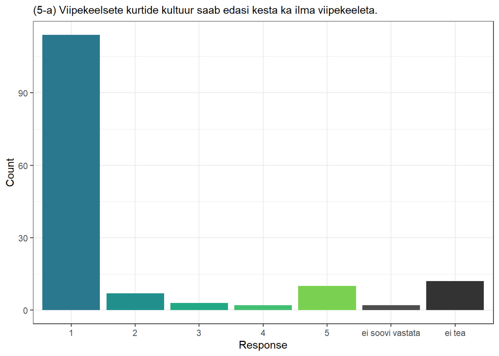